# Nanofish: Predatory performance

# Set up environment

## Load libraries

## Load functions

## Load data

### Adjust classes and transformations

```
'data.frame':   467 obs. of  30 variables:
 $ StudyID             : Factor w/ 59 levels "2","3","4","5",..: 40 40 50 50 50 50 16 16 16 7 ...
 $ StudyCluster        : Factor w/ 34 levels "1","2","3","5",..: 4 4 5 5 5 5 4 4 4 18 ...
 $ Study               : Factor w/ 59 levels "Ašmonaitė et al., 2020",..: 1 1 2 2 2 2 3 3 3 4 ...
 $ Year                : int  2020 2020 2018 2018 2018 2018 2020 2020 2020 2019 ...
 $ EScluster           : Factor w/ 101 levels "1","2","3","4",..: 1 1 2 2 2 2 3 3 3 4 ...
 $ AdministrationRoute : Factor w/ 6 levels "Food","Injection",..: 1 1 4 4 4 4 1 1 1 4 ...
 $ Concentration_mg_L  : num  NA NA 0.26 0.69 0.26 0.69 NA NA NA 20 ...
 $ ParticleMaterial    : Factor w/ 7 levels "Aminoplast","LDPE",..: 6 3 1 1 1 1 3 3 3 6 ...
 $ Species             : Factor w/ 20 levels "Argyrosomus regius",..: 9 9 8 8 8 8 9 9 9 7 ...
 $ ParticleShape       : Factor w/ 4 levels "Irregular","Sphere",..: 2 2 2 2 2 2 2 2 2 2 ...
 $ Sex                 : Factor w/ 5 levels "F","F:M","FM",..: 5 5 5 5 5 5 5 5 5 NA ...
 $ DevelopmentalStage  : Factor w/ 5 levels "Embrio","Larva",..: 4 4 4 4 4 4 4 4 4 2 ...
 $ ExposureDurationCat : Factor w/ 3 levels "15 days +","5-15 days",..: 2 2 3 3 3 3 1 1 1 3 ...
 $ ExposureDurationDays: int  14 14 4 4 4 4 28 28 28 2 ...
```

[output cut: 16 more lines]

### Calculate Effect Size

```r
df_original <- metafor::escalc(measure = "SMD", n1i = n_treat, n2i = n_ctrl, m1i = mean_treat,
    m2i = mean_ctrl, sd1i = STD_treat, sd2i = STD_ctrl, data = df_original, vtype = "UB")
# write.csv(df_original,file = 'mvMetaAnalysis_SMDs.csv')
```

### Create variables

```r
outcome <- as.character(outcomeslist[[n_outcome]])

mRF <- list()  # random effects formula investigation models
mRE <- list()  # random effects multilevel models
mMR <- list()  # multilevel metaregression models

colormap <- c(Embrio = "khaki", Larva = "lightgreen", Juvenile = "lightskyblue",
    Adult = "salmon", Unclear = "plum", ExposureDurationDays = "cornflowerblue",
    ParticleSizeMean = "chartreuse4", Concentration_mg_L = "#fa0079ff", Aminoplast = "chocolate4",
    LDPE = "#2200faff", PE = "#0089faff", PET = "#00faedff", PLA = "#00fa29ff", PS = "#faf200ff",
    PVC = "#fa9a00ff", `Publication year` = "black", Variance = "navyblue")
```

### Select outcome

```
[1] "Predatory performance"
```

|  | StudyID | StudyCluster | Study | Year | EScluster | AdministrationRoute | Concentration_mg_L | ParticleMaterial | Species | ParticleShape | Sex | DevelopmentalStage | ExposureDurationCat | ExposureDurationDays | ParticleSizeRange | ParticleSizeMean | ParticleSizeCat | Outcome | OutcomeCategory | Test_or_Assay | OutcomeVariable | Group | n_of_groups | n_ctrl | mean_ctrl | STD_ctrl | n_treat | mean_treat | STD_treat | … |
| --- | --- | --- | --- | --- | --- | --- | --- | --- | --- | --- | --- | --- | --- | --- | --- | --- | --- | --- | --- | --- | --- | --- | --- | --- | --- | --- | --- | --- | --- | --- |
| 11 | 53 | 10 | Campos et al., 2021 | 2021 | 5 | Water: Static system | 0.1 | LDPE | Argyrosomus regius | Irregular |  | Larva | up to 96h | 1 | 63-125 | 94 | micro | Predatory performance | Feeding behaviour | Ingested prey | Predatory performance | 0.1 (black circle) | 3 | 5 | 13.108 | 4.509 | 5 | 14.673 | 2.221 | … |
| 12 | 53 | 10 | Campos et al., 2021 | 2021 | 5 | Water: Static system | 1 | LDPE | Argyrosomus regius | Irregular |  | Larva | up to 96h | 1 | 63-125 | 94 | micro | Predatory performance | Feeding behaviour | Ingested prey | Predatory performance | 1 (black circle) | 3 | 5 | 13.108 | 4.509 | 5 | 8.924 | 2.894 | … |
| 13 | 53 | 10 | Campos et al., 2021 | 2021 | 5 | Water: Static system | 10 | LDPE | Argyrosomus regius | Irregular |  | Larva | up to 96h | 1 | 63-125 | 94 | micro | Predatory performance | Feeding behaviour | Ingested prey | Predatory performance | 10 (black circle) | 3 | 5 | 13.108 | 4.509 | 5 | 4.846 | 3.029 | … |
| 106 | 23 | 6 | Ferreira et al., 2016 | 2016 | 39 | Water: Semi-static system | 0.184 | PE | Pomatoschistus microps | Sphere |  | Juvenile | up to 96h | 4 | 1-5 | 3 | micro | Predatory performance | Feeding behaviour | Ingested prey | Predatory performance | MP - 20 °C | 1 | 10 | 41.106 | 12.999 | 10 | 39.546 | 16.248 | … |
| 107 | 23 | 6 | Ferreira et al., 2016 | 2016 | 40 | Water: Semi-static system | 0.184 | PE | Pomatoschistus microps | Sphere |  | Juvenile | up to 96h | 4 | 1-5 | 3 | micro | Predatory performance | Feeding behaviour | Ingested prey | Predatory performance | MP - 25 °C | 1 | 10 | 37.208 | 12.438 | 10 | 31.254 | 10.197 | … |
| 121 | 18 | 31 | Guven et al., 2018 | 2018 | 44 | Water: Static system |  | PS | Lates calcarifer | Sphere |  | Larva | up to 96h | 1 | 97 | 97 | micro | Predatory performance | Feeding behaviour | Feeding success | Predatory performance | MPs | 1 | 18 | 35.5 | 28.264 | 18 | 45.756 | 38.677 | … |
| 169 | 25 | 6 | Luís et al., 2015 | 2015 | 53 | Water: Static system | 0.216 | PE | Pomatoschistus microps | Sphere |  | Juvenile | up to 96h | 4 | 1-5 | 3 | micro | Predatory performance | Feeding behaviour | Ingested prey | Predatory performance | 0 Cr + MP (Minho river) | 1 | 9 | 66.7 | 13.17 | 5 | 50 | 13.17 | … |
| 170 | 25 | 6 | Luís et al., 2015 | 2015 | 54 | Water: Static system | 0.216 | PE | Pomatoschistus microps | Sphere |  | Juvenile | up to 96h | 4 | 1-5 | 3 | micro | Predatory performance | Feeding behaviour | Ingested prey | Predatory performance | 0 Cr + MP (Lima river) | 1 | 9 | 65.7 | 12.69 | 6 | 50 | 10.361 | … |
| 181 | 125 | 6 | Miranda et al., 2019 | 2019 | 57 | Water: Static system | 0.18 | PE | Pomatoschistus microps | Sphere |  | Juvenile | up to 96h | 4 | 1-5 | 3 | micro | Predatory performance | Feeding behaviour | Predatory performance | Predatory performance | MP - Cd +MP (Minho) | 2 | 9 | 88.599 | 7.601 | 9 | 70.705 | 19.952 | … |
| 182 | 125 | 6 | Miranda et al., 2019 | 2019 | 58 | Water: Static system | 0.18 | PE | Pomatoschistus microps | Sphere |  | Juvenile | up to 96h | 4 | 1-5 | 3 | micro | Predatory performance | Feeding behaviour | Predatory performance | Predatory performance | MP - Cd +MP (Lima) | 2 | 8 | 83.962 | 14.215 | 8 | 38.877 | 28.431 | … |

[output cut: 2 more lines]

# Exploratory data analysis

## Funnel plot

> Before running any meta-analytic model, it is important to explore the meta-analytic dataset to search for potential outliers that could represent data extraction errors. (Nakagawa et al. 2022)

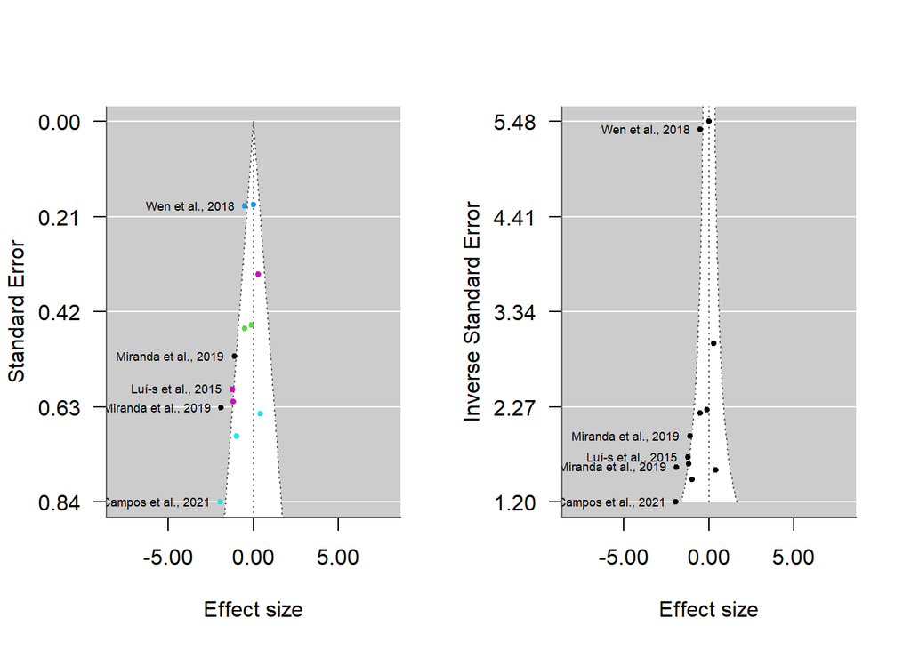

## Alluvial plot

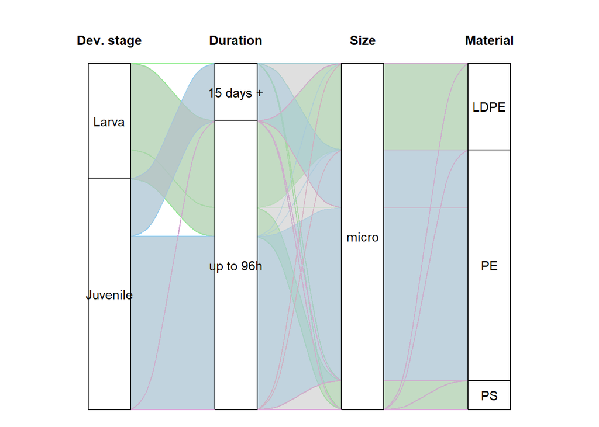

# Multilevel meta-analytic model

## Random effects formula desing

```
[1] "Considering number of studies: 6, number of ES clusters: 10 and number of independent observations of ES: 12, the random effects formula for Predatory performance is: ~1 | Study/EScluster/ESid"
```

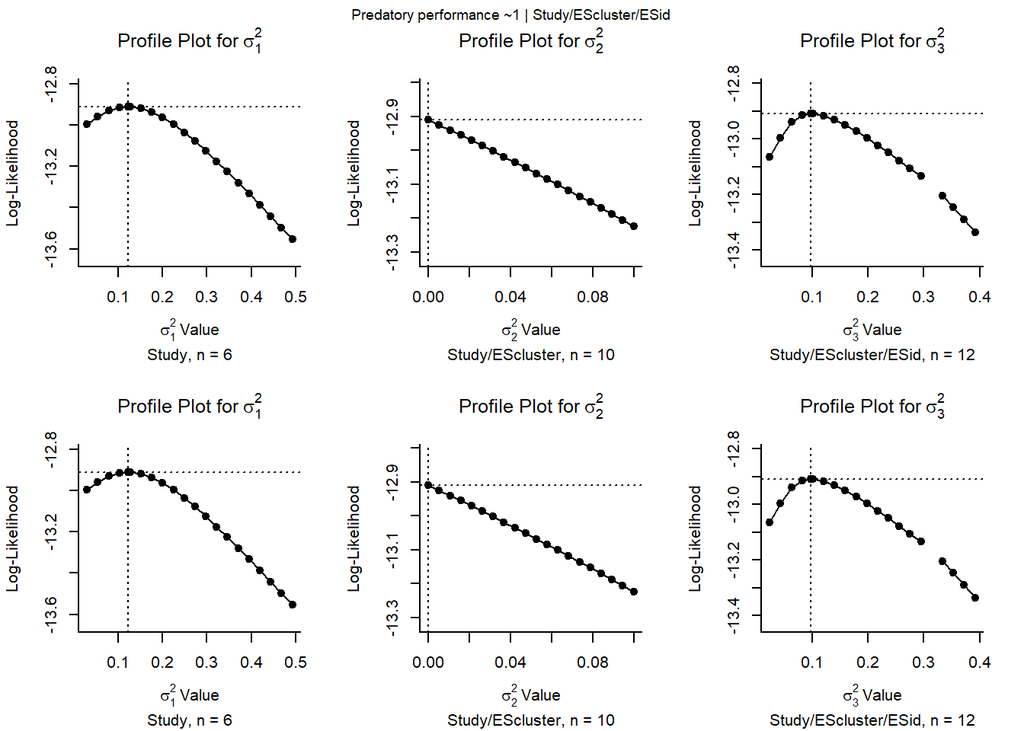

> A profile likelihood plot should show a single peak at the corresponding ML/REML estimate. If `refline=TRUE` (the default), the value of the parameter estimate is indicated by a dotted vertical line and its log-likelihood value by a dotted horizontal line. Hence, the intersection of these two lines should correspond to the peak (assuming that the model was fitted with ML/REML estimation).

> When profiling a variance component (or some other parameter that cannot be negative), the peak may be at zero (if this corresponds to the ML/REML estimate of the parameter). In this case, the profiled log-likelihood should be a monotonically decreasing function of the parameter. Similarly, when profiling a correlation component, the peak may be at -1 or +1.

> If the profiled log-likelihood has multiple peaks, this indicates that the likelihood surface is not unimodal. In such cases, the ML/REML estimate may correspond to a local optimum (when the intersection of the two dotted lines is not at the highest peak).

> If the profile is flat (over the entire parameter space or large portions of it), then this suggests that at least some of the parameters of the model are not identifiable (and the parameter estimates obtained are to some extent arbitrary). See Raue et al. (2009) for some further discussion of parameter identifiability and the use of profile likelihoods to check for this.

> The function checks whether any profiled log-likelihood value is actually larger than the log-likelihood of the fitted model (using a numerical tolerance of `lltol`). If so, a warning is issued as this might indicate that the optimizer did not identify the actual ML/REML estimate of the parameter profiled.[Viechtbauer (2022)](Viechtbauer 2010)

## Additional random effects factors

Study cluster, particle material and species as random effects term can further improve results?

|  | Nested | +StudyCluster | +Particle Material | +Species |
| --- | --- | --- | --- | --- |
| logLik: | -12.90962281476306 | -12.89603578162407 | -12.90962281489119 | -12.89603578162406 |
| deviance: | 22.14926011824665 | 22.12208605196868 | 22.14926011850291 | 22.12208605196865 |
| AIC: | 33.81924562952611 | 35.79207156324814 | 35.81924562978237 | 35.79207156324811 |
| BIC: | 35.75887222867811 | 38.21660481218814 | 38.24377887872238 | 38.21660481218812 |
| AICc: | 39.53353134381182 | 45.79207156324814 | 45.81924562978237 | 45.79207156324811 |

|  | Comparison | LRT | p_value |
| --- | --- | --- | --- |
| 1 | +Study Cluster | 0.03 | 0.869 |
| 2 | +Particle Material | 0 | 1 |
| 3 | +Species | 0.03 | 0.869 |

## Main result: Multilevel model with $\rho = 0.5$ and robust variance estimate

```r
# Assumed correlation of rho = 0.5, except if there is only one ES by Study (no
# correlation)
if (nES == nSt) {
    VCVrho <- 0
    VCV <- df$vi
} else {
    VCVrho <- 0.5
    VCV <- vcalc(vi, cluster = interaction(df$EScluster, df$Study), obs = ESid, data = df,
        rho = VCVrho)
}

mname1 <- "ML"
mname2 <- paste0(mname1, "_RobVar")

mRE[[mname1]] <- rma.mv(yi, VCV, random = RE_formula, data = df, slab = Study, method = "REML",
    test = "t", dfs = "contain", level = 95)
mRE[[mname1]] <- additional_results(mRE[[mname1]])

mRE[[mname2]] <- robust(mRE[[mname1]], cluster = df$Study, clubSandwich = TRUE)

mRE[[mname2]] <- additional_results(mRE[[mname2]])

I2_ML_RobVar <- i2_ml(mRE[[mname2]])
# I2_ML_RobVar <- i2_ml(mRE[[mname2]], boot = 1000)

extract_report(mRE[[mname2]], outcome, RE_formula)
```

#### Diagnostics plots and results

```
Multivariate Meta-Analysis Model (k = 12; method: REML)

  logLik  Deviance       AIC       BIC      AICc
-12.9973   25.9945   33.9945   35.5861   40.6612

Variance Components:

            estim    sqrt  nlvls  fixed                factor
sigma^2.1  0.0907  0.3012      6     no                 Study
sigma^2.2  0.0000  0.0000     10     no       Study/EScluster
sigma^2.3  0.2846  0.5335     12     no  Study/EScluster/ESid

Test for Heterogeneity:
Q(df = 11) = 31.3331, p-val = 0.0010

Number of estimates:   12
Number of clusters:    6
Estimates per cluster: 0-3 (mean: 0.20, median: 0)

Model Results:

estimate      se¹     tval¹    df¹    pval¹    ci.lb¹   ci.ub¹
 -0.5757  0.2491   -2.3106   4.64   0.0730   -1.2315   0.0802   .

---
Signif. codes:  0 '***' 0.001 '**' 0.01 '*' 0.05 '.' 0.1 ' ' 1

1) results based on cluster-robust inference (var-cov estimator: CR2,
   approx t-test and confidence interval, df: Satterthwaite approx)
```

```
[1] 0.242 0.000 0.758
```

```
               I2_Total                I2_Study      I2_Study/EScluster
           7.199732e+01            1.739870e+01            8.126422e-08
I2_Study/EScluster/ESid
           5.459862e+01
```

```
$results
        % of total variance   I2
Level 1        2.800268e+01  ---
Level 2        5.459862e+01 54.6
Level 3        8.126422e-08    0
Level 4        1.739870e+01 17.4

$totalI2
[1] 71.99732

$plot
```

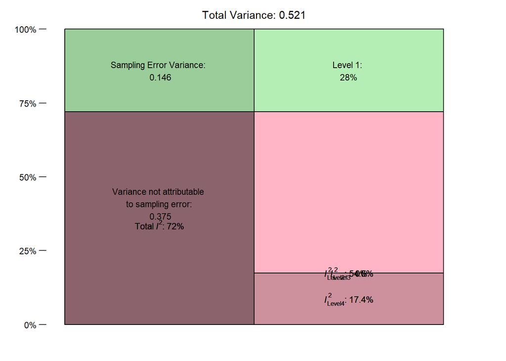

```
attr(,"class")
[1] "mlm.variance.distribution" "list"
```

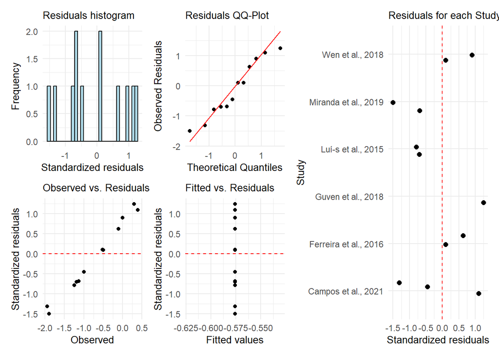

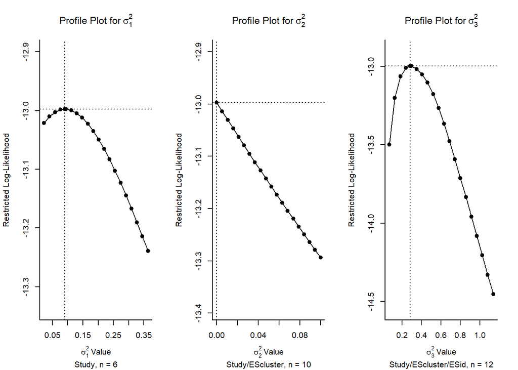

### Forest plot

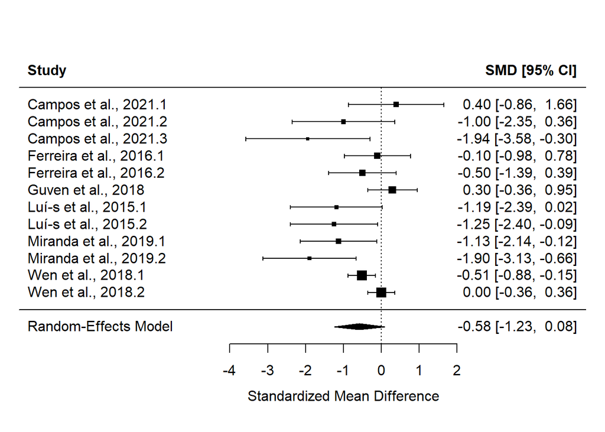

The meta-analysis comprised 12 comparisons from 10 control group clusters of 6 independent studies, so the random formula for Predatory performance was ~1 | Study/EScluster/ESid.

No difference between treatment and control groups (ES = -0.5756679 ± 0.249138, CI95% = -1.231541 to 0.0802052, predicted interval -2.3167297 to 1.1653939), with high heterogeneity (i² = 72, Q = 31.3331443, p < 0.001 ) and variance explained by each component of $\sigma^2_{Study} = 0.09$, $\sigma^2_{EScluster} = 0.00$, $\sigma^2_{ESid} = 0.28$.

# Publication bias

> **Small-study effect:** when small studies (with small sample sizes) tend to report large effect sizes. (Yang et al. 2023)

> While the PET method works best when the true effect captured by β0β0 is **zero**, PEESE shows a better performance when the true effect is **not** zero. Stanley and Doucouliagos ([2014](https://bookdown.org/MathiasHarrer/Doing_Meta_Analysis_in_R/references.html#ref-stanley2014meta)) therefore proposed to combine both methods, in order to balance out their individual strengths. The resulting approach is the PET-PEESE method. PET-PEESE uses the intercept β0 of either PET or PEESE as the estimate of the corrected true effect.

> Whether PET or PEESE is used depends on the size of the intercept calculated by the PET method. When β0PET is significantly larger than zero in a one-sided test with α = 0.05, we use the intercept of PEESE as the true effect size estimate. If PET’s intercept is not significantly larger than zero, we remain with the PET estimate.

> In most implementations of regression models in *R*, it is conventional to test the significance of coefficients using a two-sided test (i.e. we test if a ββ weight significantly differs from zero, no matter the direction). To assume a one-sided test with α = 0.05, we already regard the intercept as significant when p < 0.1, and when the estimate of β0 is larger than zero<sup>38</sup>. (Harrer et al., n.d.)

> **Time-lag bias:** when statistically significant (“positive” results) tend to be published earlier than those with statistically non-significant findings (“negative” results), leading to a decline in reported effect sizes over time (i.e., a decline effect). (Yang et al. 2023)

> Given that high heterogeneity may invalidate publication bias test, it is best to account for the potential heterogeneity when testing publication bias. (Yang et al. 2023)

> PET-PEESE performs poorly in research areas where there are only a few studies, all studies use small samples, and where there is very high heterogeneity of results from study to study. Nonetheless, the statistical properties of conventional meta-analysis approaches are much worse than PET-PEESE under these same conditions.(Stanley 2017)

So, **better use meta-regression dataset**, but requires larger dataset to avoid possible convergence issues.

#### Plots

```
[1] "PET"
```

```
Multivariate Meta-Analysis Model (k = 12; method: REML)

  logLik  Deviance       AIC       BIC      AICc
 -8.9635   17.9270   29.9270   31.1104   71.9270

Variance Components:

            estim    sqrt  nlvls  fixed                factor
sigma^2.1  0.3004  0.5481      6     no                 Study
sigma^2.2  0.0000  0.0000     10     no       Study/EScluster
sigma^2.3  0.1054  0.3247     12     no  Study/EScluster/ESid

Test for Residual Heterogeneity:
QE(df = 9) = 22.9019, p-val = 0.0064

Number of estimates:   12
Number of clusters:    6
Estimates per cluster: 0-3 (mean: 0.20, median: 0)

Test of Moderators (coefficients 2:3):¹
F(df1 = 2, df2 = 1.38) = 1.0449, p-val = 0.5294

Model Results:

          estimate        se¹     tval¹    df¹    pval¹       ci.lb¹
intrcpt  -126.8820  285.0985   -0.4450   2.15   0.6971   -1274.9401
ESSE       -3.3410    1.7629   -1.8952   2.47   0.1738      -9.7004
Year        0.0633    0.1415    0.4477   2.15   0.6954      -0.5060
             ci.ub¹
intrcpt  1021.1760
ESSE        3.0183
Year        0.6327

---
Signif. codes:  0 '***' 0.001 '**' 0.01 '*' 0.05 '.' 0.1 ' ' 1

1) results based on cluster-robust inference (var-cov estimator: CR2,
   approx t/F-tests and confidence intervals, df: Satterthwaite approx)
```

```
 pred   se ci.lb ci.ub pi.lb pi.ub
 0.96 1.04 -4.17  6.09 -5.06  6.98
```

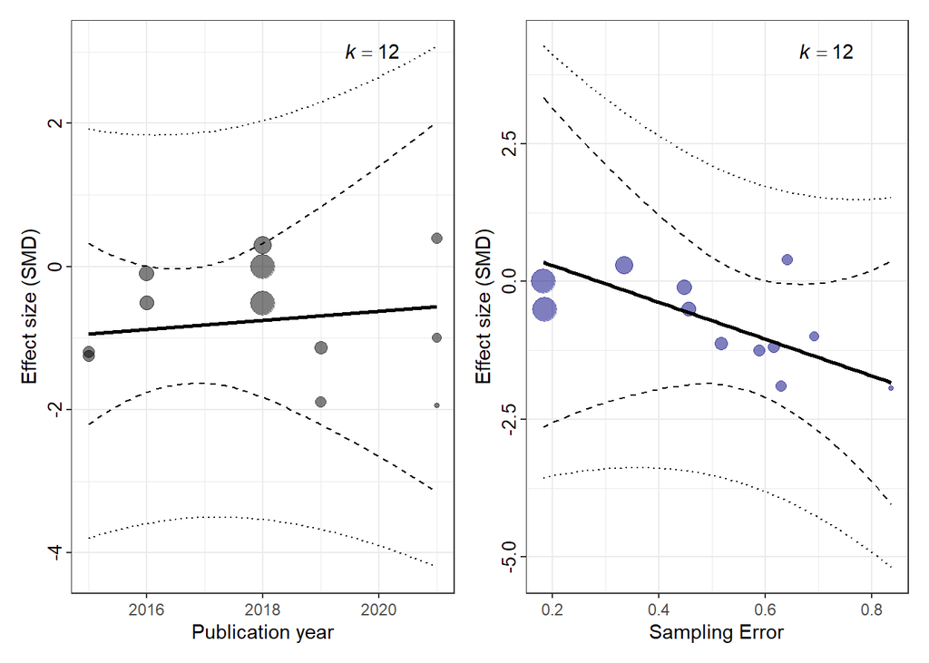

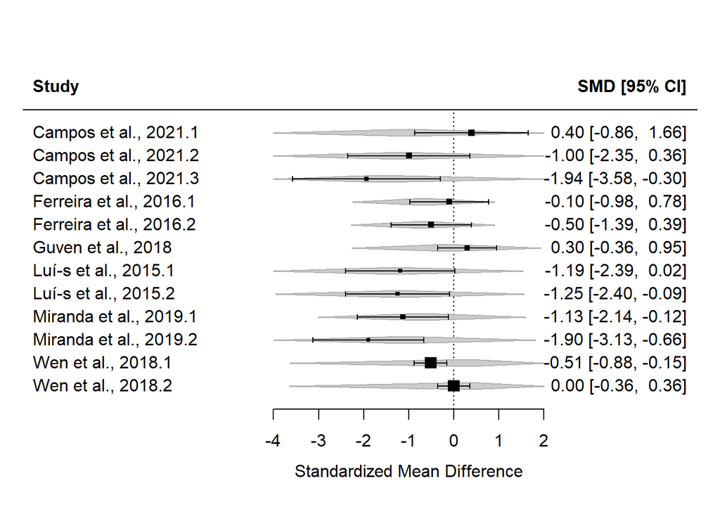

**Small-study effect** The regression slope of the extended Egger’s regression is $\sqrt{SMDSE} = -3.3410442$ is it statistically different from zero?`

If p<0.050: Smaller studies (with larger sampling error) have larger effect sizes –> small-study effect exists in this dataset. Data is assymmetrically distributed in the funnel plot.

If p>=0.050 no small-study effect exists in this dataset. Smaller studies (with larger sampling error) do not have larger effect sizes –> no small-study effect exists in this dataset. Data is symmetrically distributed in the funnel plot.

If p<0.050: studies with statistically significant findings tend to be published earlier than these with “negative” results, i.e. time-lag bias exists in this dataset

If p>=0.050: studies with statistically significant findings **do not** tend to be published earlier than these with “negative” results, i.e. no time-lag bias exists in this dataset

### Sensitivity analysis: publication bias with adapted SE

> Egger’s regression and its variants suffer from low power and poor performance when there are fewer than 20 effect sizes, or when the overall effect is large. (Nakagawa et al. 2022)

> Instead of the sample size (n1 + n2), however, for a meta-analysis of SMD or lnRR, we propose using the ‘effective sample size’ because it accounts for unbalanced sampling (cf. Stanley, 2005).(Nakagawa et al. 2022)

```r
if (mRE[[bias]]$pval[2] < 0.05) {

    # calculate modified SE based on effective sample size
    df$ess_vi <- with(df, sqrt((n_treat + n_ctrl)/(n_treat * n_ctrl)))
    df$ess_SE <- sqrt(df$ess_vi)  ## sampling error for ES

    # PET + year
    bias2 <- "PET sensitivity"
    mRE[[bias2]] <- rma.mv(yi, VCV, random = RE_formula, mods = ~ess_SE + Year, data = df,
        slab = Study, method = "REML", test = "t", dfs = "contain", level = 95)
    mRE[[bias2]] <- robust(mRE[[bias2]], cluster = df$Study, clubSandwich = TRUE)
    mRE[[bias2]] <- additional_results(mRE[[bias2]])
    mRE[[bias2]][["pi"]] <- predict(mRE[[bias2]], newmods = c(0, mean(df$Year)),
        digits = 2)

    # PEESE + year
    if (mRE[[bias2]]$pval[2] < 0.1) {
        mname <- "PEESE sensitivity"
        mRE[[mname]] <- rma.mv(yi, VCV, random = RE_formula, mods = ~ess_vi + Year,
            data = df, slab = Study, method = "REML", test = "t", dfs = "contain",
            level = 95)
        mRE[[mname]] <- robust(mRE[[mname]], cluster = df$Study, clubSandwich = TRUE)
        mRE[[mname]] <- additional_results(mRE[[mname]])
        mRE[[mname]][["pi"]] <- predict(mRE[[mname]], newmods = c(0, mean(df$Year)),
            digits = 2)
        bias2 <- mname
    }
}
```

If the results are the same, indicates the robustness of the small-study test.

#### Plots

# Sensitivity

## Rho range

```r
if (VCVrho != 0) {

    rho_range <- c(0, 0.25, 0.75, 0.9)  # assume a range values of rho

    for (j in 1:length(rho_range)) {

        mname <- paste("rho", rho_range[j], sep = "_")

        VCV2 <- vcalc(vi, cluster = interaction(df$EScluster, df$Study), obs = ESid,
            data = df, rho = rho_range[j])

        mRE[[mname]] <- rma.mv(yi, VCV2, random = RE_formula, data = df, slab = Study,
            method = "REML", test = "t", dfs = "contain", level = 95)
        mRE[[mname]] <- robust(mRE[[mname]], cluster = df$Study, clubSandwich = TRUE)
        mRE[[mname]] <- additional_results(mRE[[mname]])
    }
}
```

## Leave one out + Rho range

```r
if (VCVrho != 0) {
    rho_range <- c(0.25, 0.5, 0.75, 0.9)
} else {
    rho_range <- 0
}

for (i in sort(unique(df$Study))) {

    df_temp <- df[df$Study != i, ]

    for (j in 1:length(rho_range)) {

        mname <- paste("rho", rho_range[j], "l1o", i, sep = "_")
        print(mname)
        VCV2 <- vcalc(vi, cluster = interaction(df_temp$EScluster, df_temp$Study),
            obs = ESid, data = df_temp, rho = rho_range[j])

        mRE[[mname]] <- rma.mv(yi, VCV2, random = RE_formula, data = df_temp, slab = Study,
            method = "REML", test = "t", dfs = "contain", level = 95)
        mRE[[mname]] <- robust(mRE[[mname]], cluster = df_temp$Study, clubSandwich = TRUE)
        mRE[[mname]] <- additional_results(mRE[[mname]])
    }
}
```

```
[1] "rho_0.25_l1o_Campos et al., 2021"
[1] "rho_0.5_l1o_Campos et al., 2021"
[1] "rho_0.75_l1o_Campos et al., 2021"
[1] "rho_0.9_l1o_Campos et al., 2021"
[1] "rho_0.25_l1o_Ferreira et al., 2016"
[1] "rho_0.5_l1o_Ferreira et al., 2016"
[1] "rho_0.75_l1o_Ferreira et al., 2016"
[1] "rho_0.9_l1o_Ferreira et al., 2016"
[1] "rho_0.25_l1o_Guven et al., 2018"
[1] "rho_0.5_l1o_Guven et al., 2018"
[1] "rho_0.75_l1o_Guven et al., 2018"
[1] "rho_0.9_l1o_Guven et al., 2018"
[1] "rho_0.25_l1o_Luís et al., 2015"
[1] "rho_0.5_l1o_Luís et al., 2015"
[1] "rho_0.75_l1o_Luís et al., 2015"
[1] "rho_0.9_l1o_Luís et al., 2015"
[1] "rho_0.25_l1o_Miranda et al., 2019"
[1] "rho_0.5_l1o_Miranda et al., 2019"
[1] "rho_0.75_l1o_Miranda et al., 2019"
[1] "rho_0.9_l1o_Miranda et al., 2019"
[1] "rho_0.25_l1o_Wen et al., 2018"
[1] "rho_0.5_l1o_Wen et al., 2018"
[1] "rho_0.75_l1o_Wen et al., 2018"
[1] "rho_0.9_l1o_Wen et al., 2018"
```

# Tables

|  | n studies | n ES clusters | n ES | overall effect | standard error | p-value | Lower CI | Upper CI | Lower PI | Upper PI | Q | Q p-value | $I^2$$_{total}$ | $I^2$$_{Study}$ | $I^2$$_{EScluster}$ | $I^2$$_{ES}$ | $\sigma^2$$_{Study}$ | $\sigma^2$$_{EScluster}$ | $\sigma^2$$_{ES}$ |
| --- | --- | --- | --- | --- | --- | --- | --- | --- | --- | --- | --- | --- | --- | --- | --- | --- | --- | --- | --- |
| ML | 6 | 10 | 12 | -0.58 | 0.3 | 0.0702 | -1.22 | 0.07 | -2.28 | 1.13 | 31.33 | 0.00 | 72.00 | 17.40 | 0.00 | 54.60 | 0.09 | 0.00 | 0.28 |
| ML_RobVar | 6 | 10 | 12 | -0.58 | 0.2 | 0.0730 | -1.23 | 0.08 | -2.32 | 1.17 | 31.33 | 0.00 | 72.00 | 17.40 | 0.00 | 54.60 | 0.09 | 0.00 | 0.28 |
| PET | 6 | 10 | 12 | -126.88 | 285.1 | 0.6971 | -1274.94 | 1021.18 | -5.06 | 6.98 | 22.90 | 0.01 | 73.54 | 54.43 | 0.00 | 19.11 | 0.30 | 0.00 | 0.11 |
| rho_0 | 6 | 10 | 12 | -0.56 | 0.2 | 0.0733 | -1.20 | 0.08 | -2.11 | 0.99 | 26.87 | 0.00 | 66.81 | 46.15 | 0.00 | 20.66 | 0.20 | 0.00 | 0.09 |
| rho_0.25 | 6 | 10 | 12 | -0.56 | 0.2 | 0.0770 | -1.21 | 0.09 | -2.17 | 1.05 | 28.21 | 0.00 | 68.60 | 37.30 | 0.00 | 31.29 | 0.17 | 0.00 | 0.15 |
| rho_0.75 | 6 | 10 | 12 | -0.59 | 0.2 | 0.0700 | -1.26 | 0.07 | -2.49 | 1.31 | 41.04 | 0.00 | 75.51 | 0.00 | 0.00 | 75.51 | 0.00 | 0.00 | 0.45 |
| rho_0.9 | 6 | 10 | 12 | -0.60 | 0.3 | 0.0697 | -1.27 | 0.07 | -2.62 | 1.42 | 70.24 | 0.00 | 77.96 | 0.00 | 0.00 | 77.96 | 0.00 | 0.00 | 0.52 |
| rho_0.25_l1o_Campos et al., 2021 | 5 | 9 | 9 | -0.54 | 0.3 | 0.1476 | -1.39 | 0.30 | -2.46 | 1.37 | 21.04 | 0.01 | 76.26 | 65.27 | 5.49 | 5.49 | 0.32 | 0.03 | 0.03 |
| rho_0.5_l1o_Campos et al., 2021 | 5 | 9 | 9 | -0.54 | 0.3 | 0.1476 | -1.39 | 0.30 | -2.46 | 1.37 | 21.04 | 0.01 | 76.26 | 65.27 | 5.49 | 5.49 | 0.32 | 0.03 | 0.03 |
| rho_0.75_l1o_Campos et al., 2021 | 5 | 9 | 9 | -0.54 | 0.3 | 0.1476 | -1.39 | 0.30 | -2.46 | 1.37 | 21.04 | 0.01 | 76.26 | 65.27 | 5.49 | 5.49 | 0.32 | 0.03 | 0.03 |
| rho_0.9_l1o_Campos et al., 2021 | 5 | 9 | 9 | -0.54 | 0.3 | 0.1476 | -1.39 | 0.30 | -2.46 | 1.37 | 21.04 | 0.01 | 76.26 | 65.27 | 5.49 | 5.49 | 0.32 | 0.03 | 0.03 |
| rho_0.25_l1o_Ferreira et al., 2016 | 5 | 8 | 10 | -0.65 | 0.3 | 0.1033 | -1.51 | 0.21 | -2.70 | 1.41 | 27.79 | 0.00 | 75.63 | 34.77 | 0.00 | 40.87 | 0.20 | 0.00 | 0.24 |
| rho_0.5_l1o_Ferreira et al., 2016 | 5 | 8 | 10 | -0.67 | 0.3 | 0.0985 | -1.54 | 0.20 | -2.87 | 1.54 | 30.92 | 0.00 | 78.12 | 15.90 | 0.00 | 62.22 | 0.10 | 0.00 | 0.40 |
| rho_0.75_l1o_Ferreira et al., 2016 | 5 | 8 | 10 | -0.69 | 0.3 | 0.0963 | -1.57 | 0.20 | -3.05 | 1.68 | 40.63 | 0.00 | 80.37 | 1.12 | 0.00 | 79.25 | 0.01 | 0.00 | 0.57 |
| rho_0.9_l1o_Ferreira et al., 2016 | 5 | 8 | 10 | -0.69 | 0.3 | 0.0962 | -1.59 | 0.20 | -3.17 | 1.78 | 69.85 | 0.00 | 81.87 | 0.00 | 0.00 | 81.87 | 0.00 | 0.00 | 0.64 |
| rho_0.25_l1o_Guven et al., 2018 | 5 | 9 | 11 | -0.69 | 0.3 | 0.0568 | -1.42 | 0.03 | -2.33 | 0.94 | 24.06 | 0.01 | 63.09 | 32.23 | 0.00 | 30.86 | 0.13 | 0.00 | 0.13 |
| rho_0.5_l1o_Guven et al., 2018 | 5 | 9 | 11 | -0.70 | 0.3 | 0.0607 | -1.45 | 0.05 | -2.53 | 1.14 | 27.28 | 0.00 | 68.81 | 15.54 | 0.00 | 53.27 | 0.08 | 0.00 | 0.26 |
| rho_0.75_l1o_Guven et al., 2018 | 5 | 9 | 11 | -0.70 | 0.3 | 0.0633 | -1.47 | 0.07 | -2.75 | 1.35 | 37.16 | 0.00 | 73.84 | 0.00 | 0.00 | 73.84 | 0.00 | 0.00 | 0.43 |
| rho_0.9_l1o_Guven et al., 2018 | 5 | 9 | 11 | -0.71 | 0.3 | 0.0618 | -1.48 | 0.06 | -2.89 | 1.48 | 66.79 | 0.00 | 76.79 | 0.00 | 0.00 | 76.79 | 0.00 | 0.00 | 0.51 |
| rho_0.25_l1o_Luís et al., 2015 | 5 | 8 | 10 | -0.46 | 0.3 | 0.1532 | -1.18 | 0.27 | -2.20 | 1.29 | 23.83 | 0.00 | 70.13 | 26.08 | 0.00 | 44.04 | 0.11 | 0.00 | 0.19 |
| rho_0.5_l1o_Luís et al., 2015 | 5 | 8 | 10 | -0.47 | 0.3 | 0.1489 | -1.21 | 0.28 | -2.40 | 1.46 | 26.87 | 0.00 | 74.06 | 5.86 | 0.00 | 68.21 | 0.03 | 0.00 | 0.34 |
| rho_0.75_l1o_Luís et al., 2015 | 5 | 8 | 10 | -0.48 | 0.3 | 0.1516 | -1.25 | 0.29 | -2.63 | 1.67 | 36.43 | 0.00 | 78.32 | 0.00 | 0.00 | 78.32 | 0.00 | 0.00 | 0.47 |
| rho_0.9_l1o_Luís et al., 2015 | 5 | 8 | 10 | -0.48 | 0.3 | 0.1539 | -1.27 | 0.30 | -2.78 | 1.81 | 65.26 | 0.00 | 80.68 | 0.00 | 0.00 | 80.68 | 0.00 | 0.00 | 0.55 |
| rho_0.25_l1o_Miranda et al., 2019 | 5 | 8 | 10 | -0.38 | 0.2 | 0.1234 | -0.93 | 0.18 | -1.75 | 0.99 | 19.44 | 0.02 | 55.53 | 0.00 | 0.00 | 55.53 | 0.00 | 0.00 | 0.17 |
| rho_0.5_l1o_Miranda et al., 2019 | 5 | 8 | 10 | -0.39 | 0.2 | 0.1300 | -0.97 | 0.20 | -2.00 | 1.22 | 22.44 | 0.01 | 65.11 | 0.00 | 0.00 | 65.11 | 0.00 | 0.00 | 0.25 |
| rho_0.75_l1o_Miranda et al., 2019 | 5 | 8 | 10 | -0.40 | 0.2 | 0.1322 | -1.01 | 0.20 | -2.31 | 1.50 | 31.93 | 0.00 | 73.78 | 0.00 | 0.00 | 73.78 | 0.00 | 0.00 | 0.37 |
| rho_0.9_l1o_Miranda et al., 2019 | 5 | 8 | 10 | -0.41 | 0.2 | 0.1328 | -1.03 | 0.21 | -2.50 | 1.67 | 60.61 | 0.00 | 77.58 | 0.00 | 0.00 | 77.58 | 0.00 | 0.00 | 0.46 |
| rho_0.25_l1o_Wen et al., 2018 | 5 | 8 | 10 | -0.69 | 0.3 | 0.0879 | -1.54 | 0.16 | -2.70 | 1.32 | 22.65 | 0.01 | 59.92 | 22.34 | 0.00 | 37.58 | 0.16 | 0.00 | 0.27 |
| rho_0.5_l1o_Wen et al., 2018 | 5 | 8 | 10 | -0.72 | 0.3 | 0.0786 | -1.57 | 0.13 | -2.86 | 1.42 | 26.00 | 0.00 | 63.14 | 4.65 | 0.00 | 58.49 | 0.04 | 0.00 | 0.45 |
| rho_0.75_l1o_Wen et al., 2018 | 5 | 8 | 10 | -0.73 | 0.3 | 0.0783 | -1.59 | 0.13 | -3.04 | 1.58 | 36.09 | 0.00 | 66.76 | 0.00 | 0.00 | 66.76 | 0.00 | 0.00 | 0.57 |
| rho_0.9_l1o_Wen et al., 2018 | 5 | 8 | 10 | -0.73 | 0.3 | 0.0790 | -1.60 | 0.14 | -3.15 | 1.69 | 66.03 | 0.00 | 69.06 | 0.00 | 0.00 | 69.06 | 0.00 | 0.00 | 0.64 |

|  | ML | ML_RobVar | PET | rho_0 | rho_0.25 | rho_0.75 | rho_0.9 | rho_0.25_l1o_Campos.et.al...2021 | rho_0.5_l1o_Campos.et.al...2021 | rho_0.75_l1o_Campos.et.al...2021 | rho_0.9_l1o_Campos.et.al...2021 | rho_0.25_l1o_Ferreira.et.al...2016 | rho_0.5_l1o_Ferreira.et.al...2016 | rho_0.75_l1o_Ferreira.et.al...2016 | rho_0.9_l1o_Ferreira.et.al...2016 | rho_0.25_l1o_Guven.et.al...2018 | rho_0.5_l1o_Guven.et.al...2018 | rho_0.75_l1o_Guven.et.al...2018 | rho_0.9_l1o_Guven.et.al...2018 | rho_0.25_l1o_Luí.s.et.al...2015 | rho_0.5_l1o_Luí.s.et.al...2015 | rho_0.75_l1o_Luí.s.et.al...2015 | rho_0.9_l1o_Luí.s.et.al...2015 | rho_0.25_l1o_Miranda.et.al...2019 | rho_0.5_l1o_Miranda.et.al...2019 | rho_0.75_l1o_Miranda.et.al...2019 | rho_0.9_l1o_Miranda.et.al...2019 | rho_0.25_l1o_Wen.et.al...2018 | rho_0.5_l1o_Wen.et.al...2018 | … |
| --- | --- | --- | --- | --- | --- | --- | --- | --- | --- | --- | --- | --- | --- | --- | --- | --- | --- | --- | --- | --- | --- | --- | --- | --- | --- | --- | --- | --- | --- | --- |
| logLik: | -12.99727228849722 | -12.99727228849722 | -8.963505897659275 | -12.20640181578634 | -12.58081140141013 | -13.36399986668256 | -13.57305662841956 | -7.531228018717655 | -7.531228018717655 | -7.531228018717655 | -7.531228018717655 | -11.11879442793015 | -11.39485325978012 | -11.63474462309603 | -11.76993605646575 | -11.02653022869153 | -11.50863815008664 | -11.92535375387846 | -12.15426047092642 | -10.55784665471863 | -10.87341166761025 | -11.16408368166221 | -11.34209630372557 | -9.498083194406792 | -9.89537966547704 | -10.33546692568272 | -10.59379074675066 | -11.20011521314003 | -11.4461218913119 | … |
| deviance: | 25.99454457699444 | 25.99454457699444 | 17.92701179531855 | 24.41280363157267 | 25.16162280282027 | 26.72799973336512 | 27.14611325683913 | 15.06245603743531 | 15.06245603743531 | 15.06245603743531 | 15.06245603743531 | 22.2375888558603 | 22.78970651956024 | 23.26948924619206 | 23.53987211293149 | 22.05306045738305 | 23.01727630017328 | 23.85070750775692 | 24.30852094185284 | 21.11569330943725 | 21.74682333522049 | 22.32816736332442 | 22.68419260745113 | 18.99616638881358 | 19.79075933095408 | 20.67093385136543 | 21.18758149350132 | 22.40023042628006 | 22.8922437826238 | … |
| AIC: | 33.99454457699444 | 33.99454457699444 | 29.92701179531855 | 32.41280363157267 | 33.16162280282027 | 34.72799973336512 | 35.14611325683913 | 23.06245603743531 | 23.06245603743531 | 23.06245603743531 | 23.06245603743531 | 30.2375888558603 | 30.78970651956024 | 31.26948924619206 | 31.53987211293149 | 30.05306045738305 | 31.01727630017328 | 31.85070750775692 | 32.30852094185284 | 29.11569330943725 | 29.74682333522049 | 30.32816736332442 | 30.68419260745113 | 26.99616638881358 | 27.79075933095408 | 28.67093385136543 | 29.18758149350132 | 30.40023042628006 | 30.8922437826238 | … |
| BIC: | 35.58612566818792 | 35.58612566818792 | 31.11035925933587 | 34.00438472276615 | 34.75320389401375 | 36.3195808245586 | 36.73769434803261 | 23.38022220415465 | 23.38022220415465 | 23.38022220415465 | 23.38022220415465 | 31.02648716520518 | 31.57860482890512 | 32.05838755553694 | 32.32877042227637 | 31.26340082935923 | 32.22761667214947 | 33.06104787973311 | 33.51886131382902 | 29.90459161878213 | 30.53572164456537 | 31.1170656726693 | 31.47309091679601 | 27.78506469815846 | 28.57965764029896 | 29.45983216071031 | 29.9764798028462 | 31.18912873562494 | 31.68114209196868 | … |
| AICc: | 40.66121124366111 | 40.66121124366111 | 71.92701179531855 | 39.07947029823934 | 39.82828946948693 | 41.39466640003178 | 41.81277992350579 | 36.39578937076864 | 36.39578937076864 | 36.39578937076864 | 36.39578937076864 | 40.2375888558603 | 40.78970651956024 | 41.26948924619206 | 41.53987211293149 | 38.05306045738305 | 39.01727630017328 | 39.85070750775692 | 40.30852094185284 | 39.11569330943725 | 39.74682333522049 | 40.32816736332443 | 40.68419260745113 | 36.99616638881358 | 37.79075933095408 | 38.67093385136543 | 39.18758149350133 | 40.40023042628006 | 40.8922437826238 | … |

# Influential cases

> Outliers and influential cases can actually reveal patterns that may lead to new insights about study characteristics that could be acting as potential moderators (Viechtbauer and Cheung 2010)

Cook’s distance: examine what effect the deletion of the ith study has on the fitted values of all k studies simultaneously (Viechtbauer and Cheung 2010)

DFBETAS: directly examine the influence of deleting the ith case on each individual parameter estimate (Viechtbauer and Cheung 2010)

So if a point has high Cook’s Distance, use DFBETAS to identify witch estimate is mainly influenced (only makes sense for meta regression).

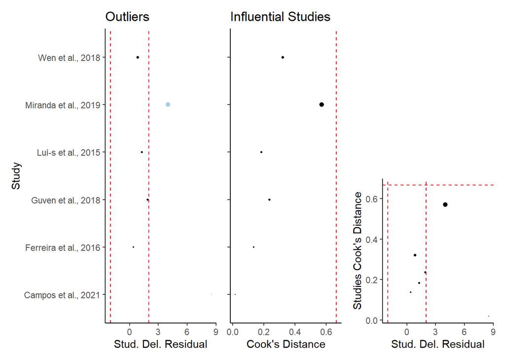

```r
influentialcases_plots(mRE, "ML_RobVar", "ML", 3)
```

# Multilevel meta-regression

SYRCLE PROTOCOL: Meta-regression will be used for outcomes with at least 10 experiments.

> The minimal number of studies or effect sizes required by a multilevel meta-regression remains unknown, albeit some simulation studies suggest that the estimates of model coefficients of a multilevel meta-regression are generally stable under various simulated situations.(Yang et al. 2023) … the complexity of parameterization of such a meta-regression requires a large dataset to make optimization algorithms free of convergence issues.(Yang et al. 2023)

## Model 1: Size, Duration, Development

```r
df_MR <- select(df, c("Year", "StudyID", "Study", "EScluster", "ESid", "DevelopmentalStage",
    "ExposureDurationDays", "ParticleSizeMean", "yi", "vi"))

mname1 <- "Base"
mname2 <- paste0(mname1, "_RobVar")

# are there differences between the different forms of DevelopmentalStage?
# mods_formula <- formula(~ ParticleSizeMean +
# ExposureDurationDays*DevelopmentalStage) at least one of the
# DevelopmentalStage levels is different than zero?
mods_formula <- formula(~0 + ParticleSizeMean + ExposureDurationDays * DevelopmentalStage)

mMR[[mname1]] <- rma.mv(yi, VCV, random = RE_formula, mods = mods_formula, data = df_MR,
    slab = Study, method = "REML", test = "t", dfs = "contain", level = 95)  #it will only keep complete cases

nSt_MR <- mMR[[mname1]]$s.nlevels[1]  # number of studies
nEC_MR <- mMR[[mname1]]$s.nlevels[2]  # number of ESclusters
nES_MR <- mMR[[mname1]]$s.nlevels[3]  # number of independent ES

print(paste0("Number of studies: ", nSt_MR, ", number of ES clusters: ", nEC_MR,
    " and number of independent observations of ES: ", nES_MR))
```

```
[1] "Number of studies: 6, number of ES clusters: 10 and number of independent observations of ES: 12"
```

```r
mMR[[mname2]] <- robust(mMR[[mname1]], cluster = df_MR$Study, clubSandwich = TRUE,
    verbose = TRUE)
```

[output not shown]

```r
mMR[[mname2]][["i2"]] <- i2_ml(mMR[[mname2]])
mMR[[mname2]][["icc"]] <- round(mMR[[mname2]]$sigma2/sum(mMR[[mname2]]$sigma2), 3)

anova(mMR[[mname2]], btt = c("DevelopmentalStage", "ExposureDurationDays", "ParticleSizeMean"))
```

```
                  spec coefs   Fval df1 df2   pval
1   DevelopmentalStage   3:4 1.8369   2   1 0.4634
2 ExposureDurationDays     2 1.7148   1   1 0.4144
3     ParticleSizeMean     1 1.8268   1   1 0.4055
```

The meta-regression comprised 12 comparisons from 10 control group clusters of 6 independent studies.

#### Diagnostics plots

```
Multivariate Meta-Analysis Model (k = 12; method: REML)

  logLik  Deviance       AIC       BIC      AICc
 -9.1551   18.3102   32.3102   32.8663  144.3102

Variance Components:

            estim    sqrt  nlvls  fixed                factor
sigma^2.1  0.1505  0.3880      6     no                 Study
sigma^2.2  0.0000  0.0000     10     no       Study/EScluster
sigma^2.3  0.2493  0.4993     12     no  Study/EScluster/ESid

Test for Residual Heterogeneity:
QE(df = 8) = 21.3443, p-val = 0.0063

Number of estimates:   12
Number of clusters:    6
Estimates per cluster: 0-3 (mean: 0.20, median: 0)

Model Results:

                            estimate       se¹     tval¹    df¹    pval¹
ParticleSizeMean              0.2989   0.2212    1.3516      1   0.4055
ExposureDurationDays         -0.8467   0.6466   -1.3095      1   0.4144
DevelopmentalStageLarva     -27.8511  20.8051   -1.3387      1   0.4084
DevelopmentalStageJuvenile    1.5332   1.9718    0.7775   1.49   0.5414
                                ci.lb¹     ci.ub¹
ParticleSizeMean              -2.5111     3.1089
ExposureDurationDays          -8.9736     7.2801
DevelopmentalStageLarva     -292.2024   236.5002
DevelopmentalStageJuvenile   -10.4955    13.5618

---
Signif. codes:  0 '***' 0.001 '**' 0.01 '*' 0.05 '.' 0.1 ' ' 1

1) results based on cluster-robust inference (var-cov estimator: CR2,
   approx t/F-tests and confidence intervals, df: Satterthwaite approx)
```

|  | ML | REML |
| --- | --- | --- |
| ll | -12.41008 | -9.155116 |
| dev | 21.84331 | 18.310231 |
| AIC | 38.82015 | 32.310231 |
| BIC | 42.21450 | 32.866322 |
| AICc | 66.82015 | 144.310231 |

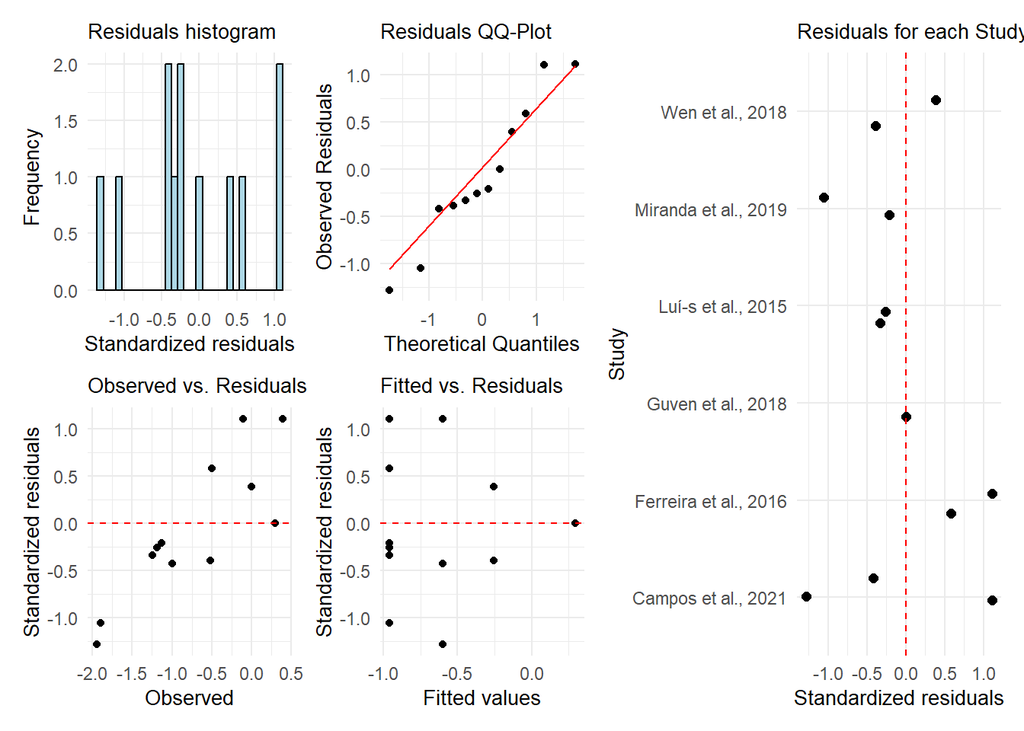

#### Influential cases

#### Orchard plots

(Nakagawa et al. 2021)

## Model 2: + Concentration

```r
df_MR <- select(df, c("Year", "StudyID", "Study", "EScluster", "ESid", "DevelopmentalStage",
    "ExposureDurationDays", "ParticleSizeMean", "Concentration_mg_L", "yi", "vi"))

mname1 <- "Conc+"
mname2 <- paste0(mname1, "_RobVar")

mods_formula <- formula(~0 + ParticleSizeMean + Concentration_mg_L + ExposureDurationDays *
    DevelopmentalStage)

mMR[[mname1]] <- rma.mv(yi, VCV, random = RE_formula, mods = mods_formula, data = df_MR,
    slab = Study, method = "REML", test = "t", dfs = "contain", level = 95)  #it will only keep complete cases

nSt_MR <- mMR[[mname1]]$s.nlevels[1]  # number of studies
nEC_MR <- mMR[[mname1]]$s.nlevels[2]  # number of ESclusters
nES_MR <- mMR[[mname1]]$s.nlevels[3]  # number of independent ES

print(paste0("Number of studies: ", nSt_MR, ", number of ES clusters: ", nEC_MR,
    " and number of independent observations of ES: ", nES_MR))
```

```
[1] "Number of studies: 5, number of ES clusters: 9 and number of independent observations of ES: 11"
```

```r
mMR[[mname2]] <- robust(mMR[[mname1]], cluster = df_MR$Study, clubSandwich = TRUE,
    verbose = TRUE)

mMR[[mname2]][["i2"]] <- i2_ml(mMR[[mname2]])
mMR[[mname2]][["icc"]] <- round(mMR[[mname2]]$sigma2/sum(mMR[[mname2]]$sigma2), 3)

anova(mMR[[mname2]], btt = c("DevelopmentalStage", "ExposureDurationDays", "ParticleSizeMean",
    "Concentration_mg_L"))
```

```
                  spec coefs    Fval df1  df2   pval
1   DevelopmentalStage     4  5.6141   1 1.99 0.1420
2 ExposureDurationDays     3  5.7746   1 1.99 0.1391
3     ParticleSizeMean     1  5.5146   1 1.99 0.1443
4   Concentration_mg_L     2 56.7450   1 1.00 0.0840 .
```

The meta-regression comprised 11 comparisons from 9 control group clusters of 5 independent studies.

#### Diagnostics plots

```
Multivariate Meta-Analysis Model (k = 11; method: REML)

  logLik  Deviance       AIC       BIC      AICc
 -6.3547   12.7095   26.7095   26.3309  138.7095

Variance Components:

            estim    sqrt  nlvls  fixed                factor
sigma^2.1  0.2255  0.4749      5     no                 Study
sigma^2.2  0.0000  0.0000      9     no       Study/EScluster
sigma^2.3  0.0835  0.2890     11     no  Study/EScluster/ESid

Test for Residual Heterogeneity:
QE(df = 7) = 14.4149, p-val = 0.0443

Number of estimates:   11
Number of clusters:    5
Estimates per cluster: 0-3 (mean: 0.19, median: 0)

Test of Moderators (coefficients 1:4):¹
F(df1 = 4, df2 = 0) = 0.0000, p-val = NA

Model Results:

                         estimate      se¹     tval¹    df¹    pval¹     ci.lb¹
ParticleSizeMean           0.1176  0.0501    2.3483   1.99   0.1443    -0.0994
Concentration_mg_L        -0.1885  0.0250   -7.5329      1   0.0840    -0.5065
ExposureDurationDays      -0.3169  0.1319   -2.4030   1.99   0.1391    -0.8884
DevelopmentalStageLarva  -10.8483  4.5785   -2.3694   1.99   0.1420   -30.6520
                          ci.ub¹
ParticleSizeMean         0.3346
Concentration_mg_L       0.1295   .
ExposureDurationDays     0.2546
DevelopmentalStageLarva  8.9554

---
Signif. codes:  0 '***' 0.001 '**' 0.01 '*' 0.05 '.' 0.1 ' ' 1

1) results based on cluster-robust inference (var-cov estimator: CR2,
   approx t/F-tests and confidence intervals, df: Satterthwaite approx)
```

|  | ML | REML |
| --- | --- | --- |
| ll | -9.472071 | -6.354747 |
| dev | 15.620109 | 12.709494 |
| AIC | 32.944143 | 26.709494 |
| BIC | 35.729410 | 26.330865 |
| AICc | 70.277476 | 138.709494 |

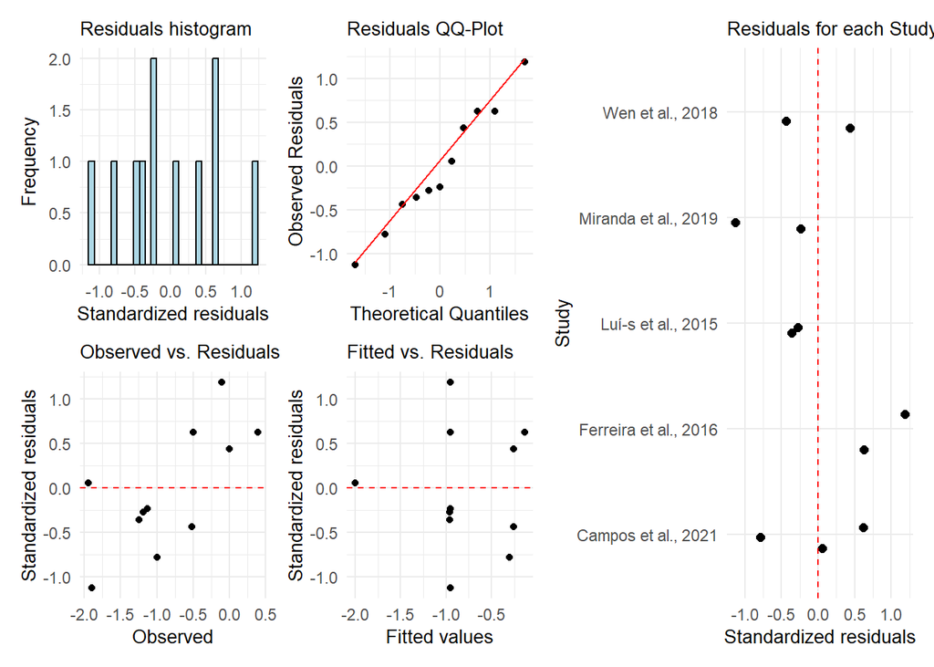

#### Influential cases

```
  Campos et al., 2021 Ferreira et al., 2016    Luís et al., 2015
                   NA              1.523995             19.531871
 Miranda et al., 2019      Wen et al., 2018
             7.322497                    NA
```

[figure not shown]

#### Orchard plots

## Model 3: + ParticleMaterial

The meta-regression comprised 11 comparisons from 9 control group clusters of 5 independent studies.

#### Diagnostics plots

[output not shown]

|  | ML | REML |
| --- | --- | --- |
| ll | -9.472071 | -6.354747 |
| dev | 15.620109 | 12.709494 |
| AIC | 32.944143 | 26.709494 |
| BIC | 35.729410 | 26.330865 |
| AICc | 70.277476 | 138.709494 |

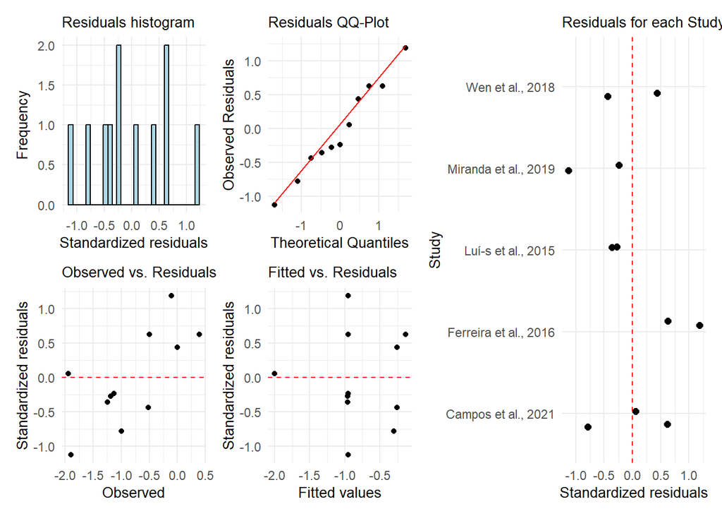

#### Influential cases

```
  Campos et al., 2021 Ferreira et al., 2016    Luís et al., 2015
                   NA              1.523995             19.531871
 Miranda et al., 2019      Wen et al., 2018
             7.322497                    NA
```

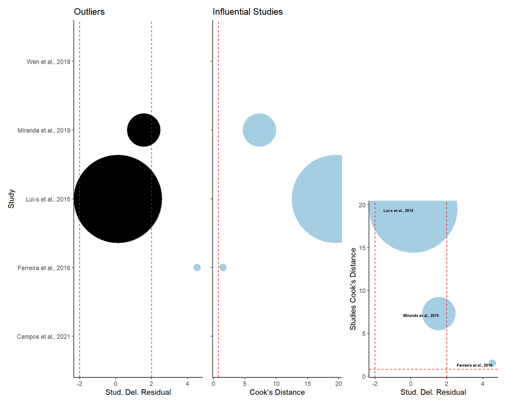

#### Orchard plots

# Referências

Harrer, Mathias, Pim Cuijpers, Toshi A. Furukawa, and David D. Ebert. n.d. *Chapter 9 Publication Bias | Doing Meta-Analysis in R*. https://bookdown.org/MathiasHarrer/Doing_Meta_Analysis_in_R/pub-bias.html.

Nakagawa, Shinichi, Malgorzata Lagisz, Michael D. Jennions, Julia Koricheva, Daniel W. A. Noble, Timothy H. Parker, Alfredo Sánchez-Tójar, Yefeng Yang, and Rose E. O’Dea. 2022. “Methods for Testing Publication Bias in Ecological and Evolutionary Meta-Analyses.” *Methods in Ecology and Evolution* 13 (1): 4–21. https://doi.org/10.1111/2041-210X.13724.

Nakagawa, Shinichi, Malgorzata Lagisz, Rose E. O’Dea, Joanna Rutkowska, Yefeng Yang, Daniel W. A. Noble, and Alistair M. Senior. 2021. “The Orchard Plot: Cultivating a Forest Plot for Use in Ecology, Evolution, and Beyond.” *Research Synthesis Methods* 12 (1): 4–12. https://doi.org/10.1002/jrsm.1424.

Stanley, T. D. 2017. “Limitations of PET-PEESE and Other Meta-Analysis Methods.” *Social Psychological and Personality Science* 8 (5): 581–91. https://doi.org/10.1177/1948550617693062.

Viechtbauer, Wolfgang. 2010. “Conducting Meta-Analyses in R with the Metafor Package.” *Journal of Statistical Software* 36 (August): 1–48. https://doi.org/10.18637/jss.v036.i03.

———. 2022. “Konstantopoulos (2011) [the Metafor Package].” https://www.metafor-project.org/doku.php/analyses:konstantopoulos2011.

Viechtbauer, Wolfgang, and Mike W.-L. Cheung. 2010. “Outlier and Influence Diagnostics for Meta-Analysis.” *Research Synthesis Methods* 1 (2): 112–25. https://doi.org/10.1002/jrsm.11.

Yang, Yefeng, Malcolm Macleod, Jinming Pan, Malgorzata Lagisz, and Shinichi Nakagawa. 2023. “Advanced Methods and Implementations for the Meta-Analyses of Animal Models: Current Practices and Future Recommendations.” *Neuroscience & Biobehavioral Reviews* 146 (March): 105016. https://doi.org/10.1016/j.neubiorev.2022.105016.